# Summary of Tier 2 NH3 Emission Factor Method

Author

Chih-Yu Hung

## Overview

This report summarized the proposed Tier 2 ammonia (`NH3-N`) emission factor outputs for animal housing and manure storage.

1. Housing emission factors are reported on a Total N basis and storage emission factors are reported on a TAN basis. Figures therefore compare patterns and relative magnitudes, but the denominator differs between the two stages.
2. We reported the same 4 broad climate zones for housing and storage: Tropical, Warm_Temperate, Cool_Temperate, and Boreal. There are 84 EFs for housing (21 animal/housing/manure combinations x 4 climates) and 32 EFs for storage (8 animal/storage/manure combinations x 1 removal schedule x 4 climates).
3. Housing EFs use row-specific indoor reference air temperature (`T_air`) and animal-specific indoor temperature equations to convert broad-zone outdoor temperature to indoor housing temperature.
4. Storage EFs use row-specific outdoor reference air temperature (`T_air`) and the April-October removal schedule as the representative schedule because prior comparisons showed low sensitivity to removal scenarios.
5. Housing Monte Carlo simulation includes uncertainties from annual outdoor temperature, reference EF, and CT. Storage Monte Carlo simulation includes uncertainties from monthly outdoor temperature, reference EF, CT, and removal efficiency.

## Data Preparation

```r
library(dplyr)
library(ggplot2)
library(knitr)
library(readr)
library(tidyr)

paths <- list(
  housing_csv = file.path("Outputs", "Proposed_Tier2_Housing.csv"),
  housing_mc_csv = file.path("Outputs", "Proposed_Tier2_Housing_MC_Summary.csv"),
  storage_csv = file.path("Outputs", "Proposed_Tier2_Storage.csv"),
  storage_mc_csv = file.path("Outputs", "Proposed_Tier2_Storage_MC_Summary.csv"),
  figure_dir = file.path("Outputs", "Summary_Tier2_Method_Figures")
)

dir.create(paths$figure_dir, showWarnings = FALSE, recursive = TRUE)

housing_climate_order <- c(
  "Tropical",
  "Warm_Temperate",
  "Cool_Temperate",
  "Boreal"
)

storage_climate_order <- c(
  "Tropical",
  "Warm_Temperate",
  "Cool_Temperate",
  "Boreal"
)

removal_schedule_order <- c(
  "April_October"
)

animal_order <- c(
  "Dairy Cattle",
  "Non-Dairy Cattle",
  "Layers",
  "Broilers",
  "Goat",
  "Sheep",
  "Swine",
  "Swine_Finising",
  "Swine_Sows and Piglets"
)

ef_fill_scale <- scale_fill_gradientn(
  colours = c("#d8ead2", "#f0df9d", "#d69a45", "#a94438"),
  limits = c(0, 1),
  name = "EF"
)

format_ef <- function(value) {
  sprintf("%.3f", value)
}

save_plot <- function(plot, file_name, width, height) {
  ggplot2::ggsave(
    filename = file.path(paths$figure_dir, file_name),
    plot = plot,
    width = width,
    height = height,
    dpi = 300,
    bg = "white"
  )
}

theme_tier2 <- function(base_size = 10) {
  theme_minimal(base_size = base_size) +
    theme(
      panel.grid = element_blank(),
      plot.title = element_text(face = "bold"),
      plot.subtitle = element_text(color = "#4f5963"),
      axis.title = element_text(face = "bold"),
      strip.text = element_text(face = "bold"),
      legend.position = "bottom"
    )
}

#Read output

housing <- readr::read_csv(paths$housing_csv, show_col_types = FALSE)
housing_mc <- readr::read_csv(paths$housing_mc_csv, show_col_types = FALSE)
storage <- readr::read_csv(paths$storage_csv, show_col_types = FALSE)
storage_mc <- readr::read_csv(paths$storage_mc_csv, show_col_types = FALSE)

housing_long <- housing %>%
  mutate(Animal_Type = factor(Animal_Type, levels = animal_order)) %>%
  tidyr::pivot_longer(
    cols = all_of(housing_climate_order),
    names_to = "Climate_zone",
    values_to = "EF_Deterministic"
  ) %>%
  mutate(
    Stage = "Housing",
    Row_Label = paste(Animal_Type, Housing, Manure_type, sep = " | "),
    Climate_zone = factor(Climate_zone, levels = housing_climate_order)
  )

housing_mc_plot <- housing_mc %>%
  mutate(
    Animal_Type = factor(Animal_Type, levels = animal_order),
    Stage = "Housing",
    Row_Label = paste(Animal_Type, Housing, Manure_type, Climate_zone, sep = " | "),
    Climate_zone = factor(Climate_zone, levels = housing_climate_order),
    MC_Width = EF_MC_Upper95 - EF_MC_Lower95
  )

storage_plot <- storage %>%
  mutate(
    Animal_Type = factor(Animal_Type, levels = animal_order),
    Stage = "Storage",
    Row_Label = paste(Animal_Type, Storage, Manure_type, sep = " | "),
    Climate_zone = factor(Climate_zone, levels = storage_climate_order),
    Removal_Schedule = factor(Removal_Schedule, levels = removal_schedule_order)
  )

storage_mc_plot <- storage_mc %>%
  mutate(
    Animal_Type = factor(Animal_Type, levels = animal_order),
    Stage = "Storage",
    Row_Label = paste(
      Animal_Type,
      Storage,
      Manure_type,
      Removal_Schedule,
      Climate_zone,
      sep = " | "
    ),
    Climate_zone = factor(Climate_zone, levels = storage_climate_order),
    Removal_Schedule = factor(Removal_Schedule, levels = removal_schedule_order),
    MC_Width = EF_MC_Upper95 - EF_MC_Lower95
  )
```

## Figure 1. Housing EF Heatmap

The results use DATAMAN EFs as the reference EF at the row-specific `T_air` from the updated correction-factor workbook. Broad climate-zone outdoor annual temperatures are converted to indoor temperatures before CT correction.

The housing heatmap shows a strong climate-temperature gradient, with highest values in the tropical zone and lowest values in the boreal zone.

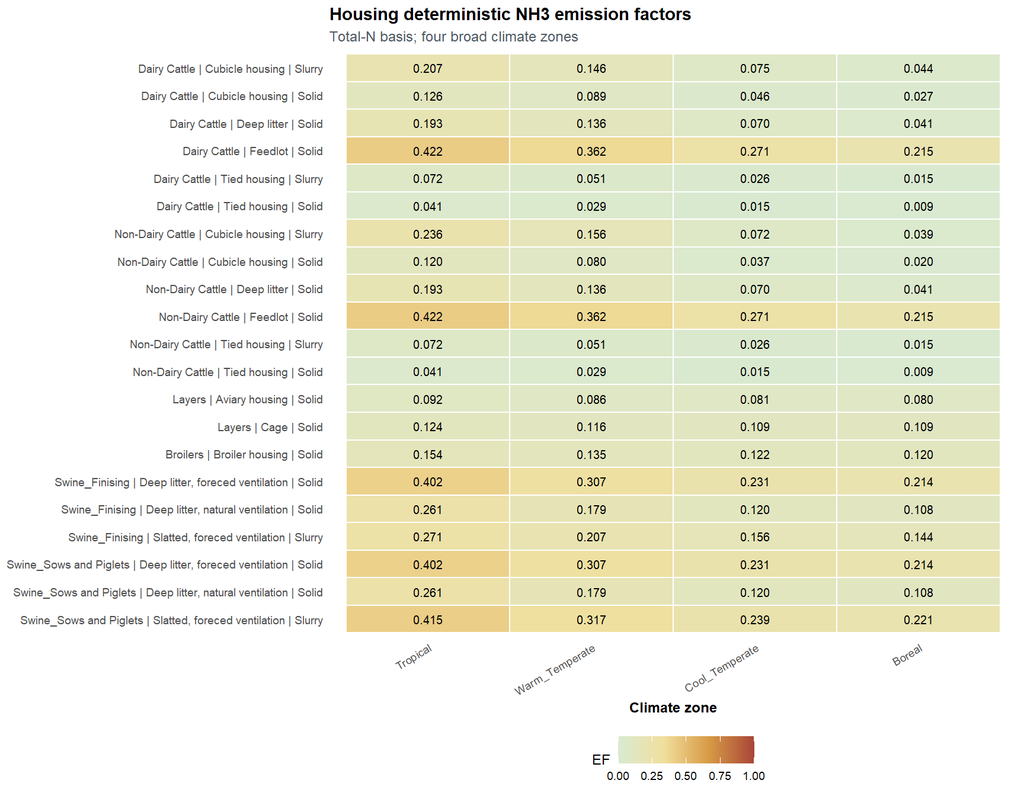

Figure 1

```r
housing_heatmap_data <- housing_long %>%
  arrange(Animal_Type, Housing, Manure_type) %>%
  mutate(Row_Label = factor(Row_Label, levels = rev(unique(Row_Label))))

fig_housing_heatmap <- ggplot(
  housing_heatmap_data,
  aes(x = Climate_zone, y = Row_Label, fill = EF_Deterministic)
) +
  geom_tile(color = "white", linewidth = 0.4) +
  geom_text(aes(label = format_ef(EF_Deterministic)), size = 2.6) +
  ef_fill_scale +
  labs(
    title = "Housing deterministic NH3 emission factors",
    subtitle = "Total-N basis; four broad climate zones",
    x = "Climate zone",
    y = NULL
  ) +
  theme_tier2(base_size = 9) +
  theme(axis.text.x = element_text(angle = 30, hjust = 1))

fig_housing_heatmap
save_plot(fig_housing_heatmap, "fig_01_housing_heatmap.png", 9, 7)
```

## Figure 2. Storage EF Heatmap

Only the April-October removal schedule is shown because previous checks found low sensitivity to removal scenarios.

The annual storage NH3 EF is calculated as:

EF = Annual NH3 emissions / Total available TAN in storage.

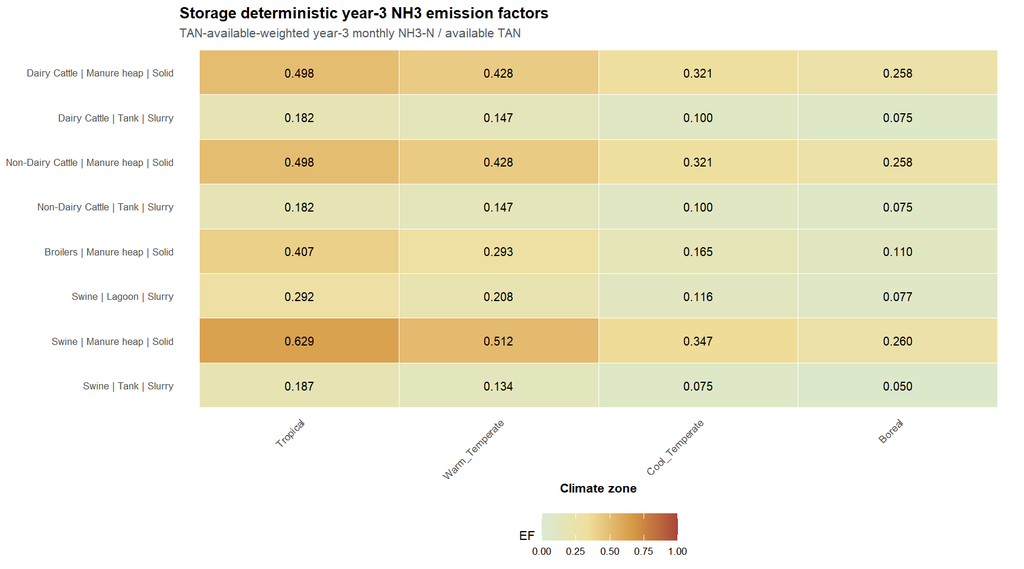

Figure 2

```r
storage_heatmap_data <- storage_plot %>%
  arrange(Animal_Type, Storage, Manure_type) %>%
  mutate(Row_Label = factor(Row_Label, levels = rev(unique(Row_Label))))

fig_storage_heatmaps <- ggplot(
  storage_heatmap_data,
  aes(x = Climate_zone, y = Row_Label, fill = Year3_EF_TAN)
) +
  geom_tile(color = "white", linewidth = 0.35) +
  geom_text(aes(label = format_ef(Year3_EF_TAN)), size = 2.6) +
  ef_fill_scale +
  labs(
    title = "Storage deterministic year-3 NH3 emission factors",
    subtitle = "TAN-available-weighted year-3 monthly NH3-N / available TAN",
    x = "Climate zone",
    y = NULL
  ) +
  theme_tier2(base_size = 8) +
  theme(
    axis.text.x = element_text(angle = 45, hjust = 1),
    panel.spacing = unit(1, "lines")
  )

fig_storage_heatmaps
save_plot(fig_storage_heatmaps, "fig_02_storage_heatmaps.png", 9, 5)
```

## Figure 3. Monte Carlo Uncertainty Intervals

Monte Carlo summaries are used to compare deterministic EFs with the mean and 95% interval of simulated EFs. Wider ranges are expected in warm temperate and tropical regions because the CT correction is exponential under warmer temperatures. Red circles are deterministic EFs and green triangles are the mean of MC simulations.

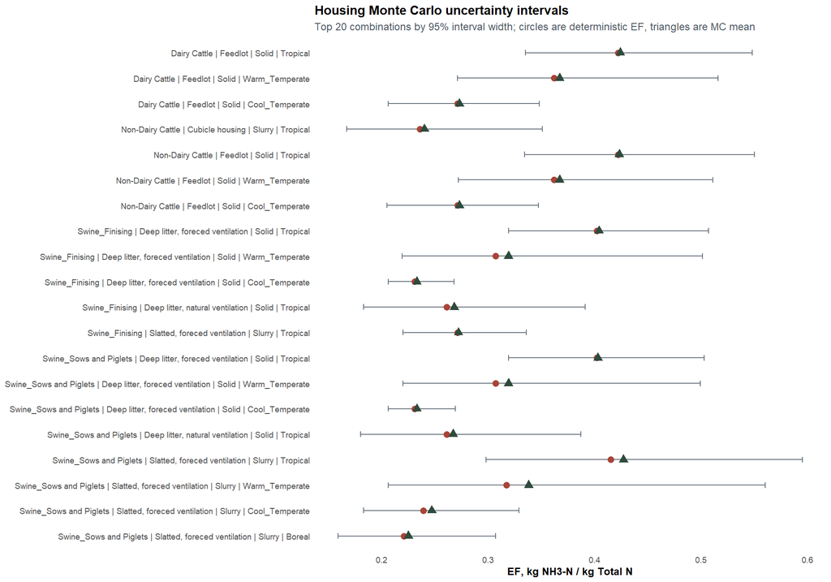

Figure 3

```r
top_housing_uncertainty <- housing_mc_plot %>%
  arrange(desc(EF_MC_Mean)) %>%
  slice_head(n = 20) %>%
  arrange(Animal_Type, Housing, Manure_type, Climate_zone) %>%
  mutate(Row_Label = factor(Row_Label, levels = rev(Row_Label)))

fig_mc_housing <- ggplot(
  top_housing_uncertainty,
  aes(x = EF_MC_Mean, y = Row_Label)
) +
  geom_errorbar(
    aes(xmin = EF_MC_Lower95, xmax = EF_MC_Upper95),
    orientation = "y",
    width = 0.22,
    color = "#69737d"
  ) +
  geom_point(aes(x = EF_Deterministic), shape = 16, size = 2.3, color = "#a94438") +
  geom_point(aes(x = EF_MC_Mean), shape = 17, size = 2.7, color = "#2e4b3d") +
  labs(
    title = "Housing Monte Carlo uncertainty intervals",
    subtitle = "Top 20 combinations by 95% interval width; circles are deterministic EF, triangles are MC mean",
    x = "EF, kg NH3-N / kg Total N",
    y = NULL
  ) +
  theme_tier2(base_size = 9)

fig_mc_housing
save_plot(fig_mc_housing, "fig_03a_housing_mc_intervals.png", 10, 7)
```

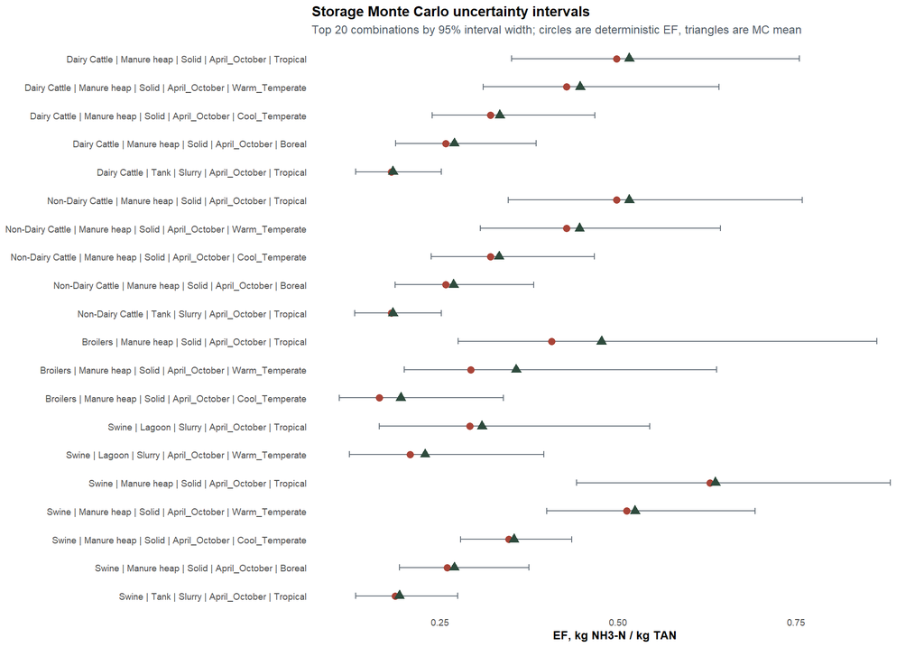

Figure 4

```r
top_storage_uncertainty <- storage_mc_plot %>%
  arrange(desc(EF_MC_Mean)) %>%
  slice_head(n = 20) %>%
  arrange(Animal_Type, Storage, Manure_type, Removal_Schedule, Climate_zone) %>%
  mutate(Row_Label = factor(Row_Label, levels = rev(Row_Label)))

fig_mc_storage <- ggplot(
  top_storage_uncertainty,
  aes(x = EF_MC_Mean, y = Row_Label)
) +
  geom_errorbar(
    aes(xmin = EF_MC_Lower95, xmax = EF_MC_Upper95),
    orientation = "y",
    width = 0.22,
    color = "#69737d"
  ) +
  geom_point(aes(x = EF_Deterministic), shape = 16, size = 2.3, color = "#a94438") +
  geom_point(aes(x = EF_MC_Mean), shape = 17, size = 2.7, color = "#2e4b3d") +
  labs(
    title = "Storage Monte Carlo uncertainty intervals",
    subtitle = "Top 20 combinations by 95% interval width; circles are deterministic EF, triangles are MC mean",
    x = "EF, kg NH3-N / kg TAN",
    y = NULL
  ) +
  theme_tier2(base_size = 9)

fig_mc_storage
save_plot(fig_mc_storage, "fig_03b_storage_mc_intervals.png", 10, 7)
```

## Figure 4. EF Distribution Comparison

This summary highlights that storage EFs are generally larger than housing EFs, while also reminding that the basis differs: TAN for storage and Total N for housing.

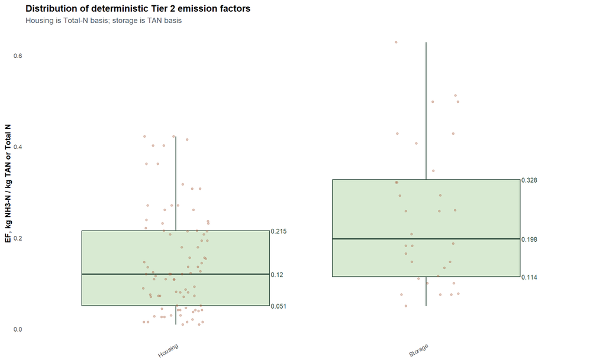

Figure 5

```r
housing_distribution <- housing_long %>%
  transmute(
    Stage_Group = "Housing",
    EF = EF_Deterministic
  )

storage_distribution <- storage_plot %>%
  transmute(
    Stage_Group = "Storage",
    EF = Year3_EF_TAN
  )

distribution_data <- bind_rows(housing_distribution, storage_distribution) %>%
  mutate(
    Stage_Group = factor(
      Stage_Group,
      levels = c("Housing", "Storage")
    )
  )


quantile_labels <- distribution_data %>%
  group_by(Stage_Group) %>%
  summarise(
    q25 = quantile(EF, 0.25, na.rm = TRUE),
    median = median(EF, na.rm = TRUE),
    q75 = quantile(EF, 0.75, na.rm = TRUE),
    .groups = "drop"
  ) %>%
  tidyr::pivot_longer(
    cols = c(q25, median, q75),
    names_to = "Statistic",
    values_to = "EF"
  ) %>%
  mutate(
    label = case_when(
      Statistic == "q25" ~ paste0(round(EF, 3)),
      Statistic == "median" ~ paste0(round(EF, 3)),
      Statistic == "q75" ~ paste0(round(EF, 3))
    )
  )


fig_distribution <- ggplot(distribution_data, aes(x = Stage_Group, y = EF)) +
  geom_boxplot(fill = "#d8ead2", color = "#2e4b3d", outlier.alpha = 0.5) +
  geom_jitter(width = 0.13, height = 0, alpha = 0.35, size = 1.1, color = "#a65b3b") +
  geom_text(
    data = quantile_labels,
    aes(x = Stage_Group, y = EF, label = label),
    inherit.aes = FALSE,
    nudge_x = 0.38,
    hjust = 0,
    size = 2.6,
    color = "#2e4b3d"
  ) +
  labs(
    title = "Distribution of deterministic Tier 2 emission factors",
    subtitle = "Housing is Total-N basis; storage is TAN basis",
    x = NULL,
    y = "EF, kg NH3-N / kg TAN or Total N"
  ) +
  theme_tier2(base_size = 9) +
  theme(
    axis.text.x = element_text(angle = 30, hjust = 1),
    plot.margin = margin(5.5, 35, 5.5, 5.5)
  ) +
  coord_cartesian(clip = "off")


fig_distribution
save_plot(fig_distribution, "fig_04_ef_distribution_comparison.png", 10, 6)
```